# Mini-Project 3: Babynames Graph

SDS 192: MP3

Faith de Castro

Smith College

Lauren Light

Smith College

Renee Wu

Smith College

February 5, 2021

## Instructions

> READ THE INSTRUCTIONS: https://beanumber.github.io/sds192/mod_babynames.html Your goal in Step 1 is to recreate this data graphic as closely as you can:

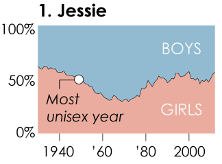

## Step 1: Make the plot for “Jessie”

### Step 1A: Gather the data for “Jessie”

```r
jessie <- babynames %>%
  filter(
    name == "Jessie",
    year >= 1930 & year < 2012
  ) %>%
  select(-prop) %>%
  pivot_wider(names_from = sex, values_from = n)%>%
  mutate(pct_girls = F / (F + M))
jessie
```

| year | name | F | M | pct_girls |
| --- | --- | --- | --- | --- |
| 1930 | Jessie | 2196 | 1330 | 0.6228020 |
| 1931 | Jessie | 1930 | 1267 | 0.6036910 |
| 1932 | Jessie | 1895 | 1282 | 0.5964747 |
| 1933 | Jessie | 1807 | 1077 | 0.6265603 |
| 1934 | Jessie | 1793 | 1091 | 0.6217060 |
| 1935 | Jessie | 1618 | 1103 | 0.5946343 |
| 1936 | Jessie | 1586 | 1013 | 0.6102347 |
| 1937 | Jessie | 1552 | 1040 | 0.5987654 |
| 1938 | Jessie | 1475 | 971 | 0.6030253 |
| 1939 | Jessie | 1396 | 1058 | 0.5688672 |

[output cut: 72 more lines]

### Step 1B: Compute the “most unisex year”

```r
jessie_unisex_year <- jessie %>%
  mutate(distance = abs(pct_girls - 0.5)) %>%
  arrange(distance) %>%
  head(1)
jessie_unisex_year
```

| year | name | F | M | pct_girls | distance |
| --- | --- | --- | --- | --- | --- |
| 1949 | Jessie | 1031 | 1023 | 0.5019474 | 0.00194742 |

### Step 1C: Add the annotations for “Jessie”

```r
jessie_context <- tribble(
  ~year_label, ~vpos, ~hjust, ~name, ~text,
  1934, 0.35, "left", "Jessie", "Most\nunisex year"
)
jessie_segments <- tribble(
  ~year, ~pct_girls, ~name,
  1940, 0.43, "Jessie",
  1940, 0.5, "Jessie",
  1949, 0.4956897, "Jessie"
)
jessie_labels <- tribble(
  ~year, ~name, ~pct_girls, ~label,
  1998, "Jessie", 0.8, "BOYS",
  1998, "Jessie", 0.2, "GIRLS"
)
```

### Step 1D: Draw the plot for “Jessie”

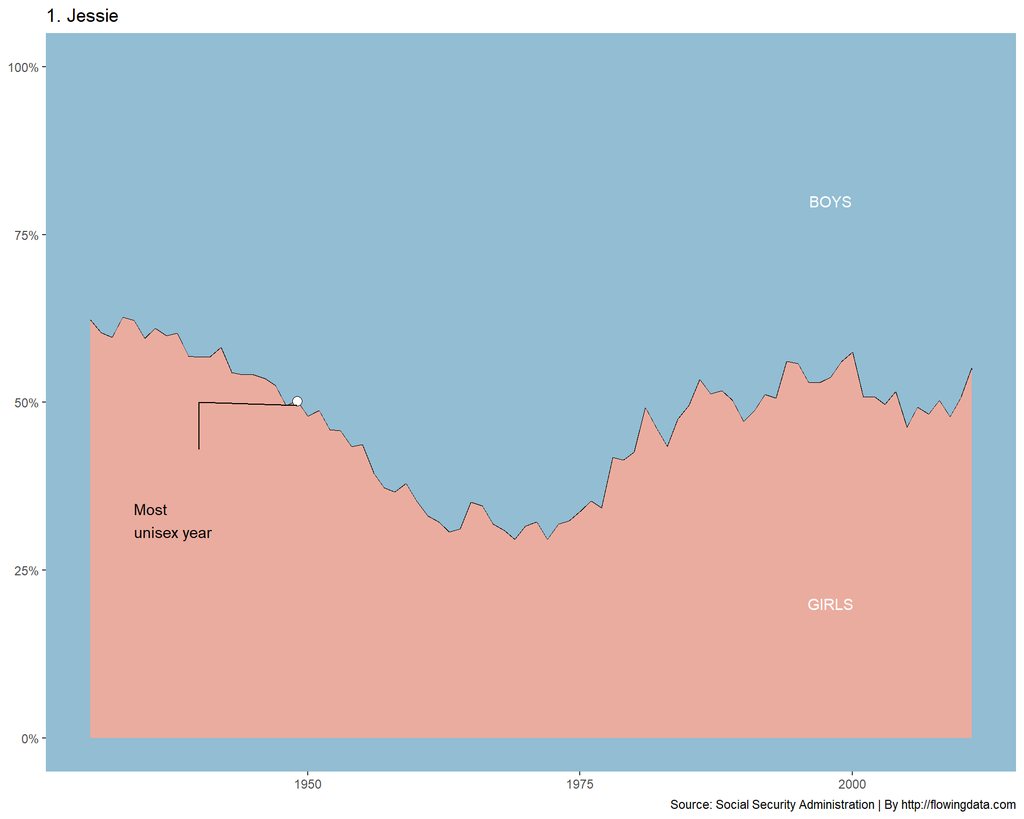

```r
ggplot(jessie, aes(x = year, y = pct_girls)) +
  geom_line() +
  geom_area(fill = "#eaac9e") +
  geom_point(data = jessie_unisex_year, fill = "white", pch = 21, size = 3) +
  geom_path(data = jessie_segments) +
  geom_text(
    data = jessie_labels,
    aes(label = label),
    color = "white"
  ) +
  geom_text(
    data = jessie_context, family = "Century Gothic",
    aes(x = year_label, y = vpos, label = text, hjust = hjust), vjust = "top"
  ) +
  scale_y_continuous(NULL,
    limits = c(0, 1),
    labels = scales::percent
  ) +
  scale_x_continuous(NULL) +
  scale_fill_manual(values = c("#eaac9e", "black")) +
  theme(
    panel.background = element_rect(fill = "#92bdd3"),
    panel.grid.major = element_blank(),
    panel.grid.minor = element_blank(),
    text = element_text(family = "Century Gothic"),
    strip.background = element_blank(),
    strip.text = element_text(hjust = 0, face = "bold", size = 14)
  ) +
  guides(fill = FALSE) +
  labs(
    title = "1. Jessie",
    caption = "Source: Social Security Administration | By http://flowingdata.com"
  )
```

## Step 2: Make the graphic for all 35 names

The Social Security Administration’s name data, collected every year going back to 1880 and through 2012, includes the number of babies born per year for each year. This information can be easily accessed through the babynames package in R. In his article “The Most Unisex Names in the US,” Nathan Yau[^1] collected and graphed the top 35 names with the most equal number of boys and girls between the years of 1930 and 2012.

In our attempt to “Replicate the Master,” the first step was collecting a list of the most popular unisex names as close to Yau’s as possible. Although this ended up being the most challenging portion of the assignment, we were able to wrangle a fairly large number of the names Yau listed. In order to generate this list, we computed the RMSE for each name, and then gathered a list of names filtered by popularity to input into the RMSE calculations to achieve a list of names that were both popular and unisex. We were running into many errors trying to complete this step, because many names had N/A sections. The sheer number of names was also difficult to filter, so we had to play around with the data until we were able to filter out names that had less than 80 appearances. By the end, our list of names shared 26/35 names with Yau’s.

```r
# Step 1: Compute top 35 names - something like finding an integral of the area under the curve and filtering out the top 35 names that come the closest to 50-50
# Step 2: Feed that list of names into iterative function that draws graphs for all names
# Step 3: Add extra annotations for the few names that have special notes.
```

Make [the full data graphic](https://i2.wp.com/flowingdata.com/wp-content/uploads/2013/09/most-unisex-names2.png?w=2000) with the 35 most gender-neutral names:

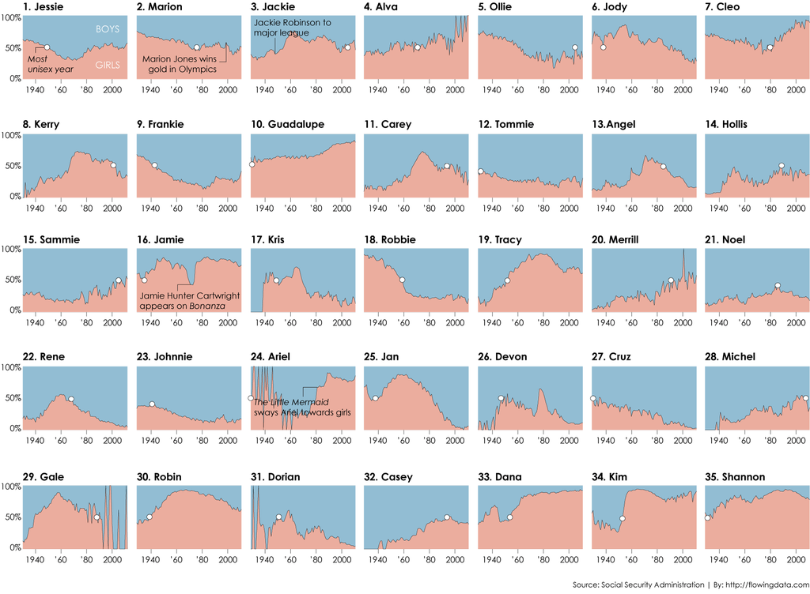

Or at least, make an attempt that’s as good as mine:

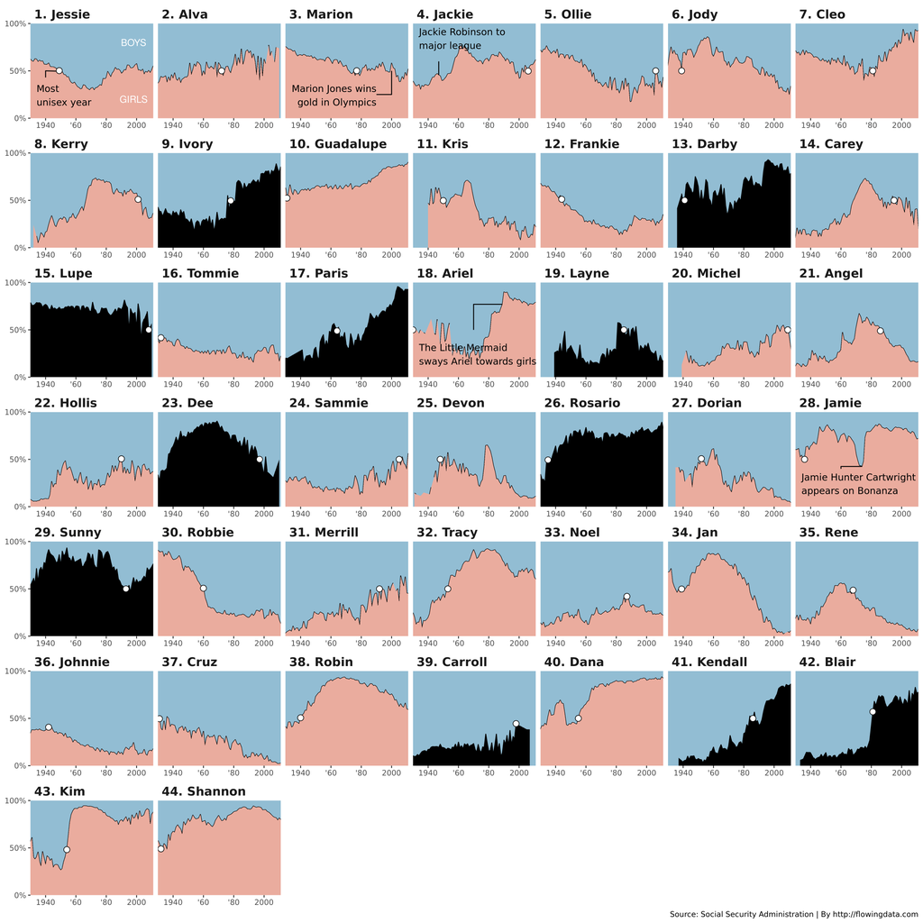

```r
fd_names <- c(
  "Jessie", "Marion", "Jackie", "Alva", "Ollie",
  "Jody", "Cleo", "Kerry", "Frankie", "Guadalupe",
  "Carey", "Tommie", "Angel", "Hollis", "Sammie",
  "Jamie", "Kris", "Robbie", "Tracy", "Merrill",
  "Noel", "Rene", "Johnnie", "Ariel", "Jan",
  "Devon", "Cruz", "Michel", "Gale", "Robin",
  "Dorian", "Casey", "Dana", "Kim", "Shannon"
) %>%
  enframe(name = "fd_rank", value = "name")
```

### Step 2A: Compute the RMSE for Jessie

```r
jessie %>%
  mutate(
    error = pct_girls - 0.5,
    squared_error = error^2
  ) %>%
  summarize(
    mse = mean(squared_error),
    rmse = sqrt(mse)
  )
```

| mse | rmse |
| --- | --- |
| 0.009980733 | 0.09990362 |

### Step 2B: Compute the RMSE for all names

```r
#function to calculate rmse for all names
rmse_names<-function(name_arg){
  babynames%>%
  filter(
    name == name_arg,
    year >= 1930 & year < 2012
  ) %>%
  select(-prop) %>%
  pivot_wider(names_from = sex, values_from = n)%>%
  na.omit()%>%
  mutate(pct_girls = F / (F + M),error = pct_girls - 0.5, squared_error = error^2)%>%
  group_by(name)%>%
  summarize(
    mse = mean(squared_error),
    rmse = sqrt(mse)
  )
}
```

### Step 2C: Rank and filter the list of names

```r
#obtains list of names filtered by popularity to input into rmse calculations
unsorted_names<-babynames%>%
  filter(year>=1930 & year<2012,name!="Unknown")%>%
  #group_by(year)%>%
  select(-prop)%>%
  pivot_wider(names_from = sex, values_from = n)%>%
  filter(is.na(M)==FALSE&is.na(F)==FALSE)%>%
  group_by(name)%>%
  summarize(num_app = n())%>%
  arrange(desc(num_app))%>%
  filter(num_app>=80)%>%
  select(name)
unsorted_names<-unsorted_names$name

#calls rmse function and arranges top 35 by rmse
sorted_names<-map_dfr(unsorted_names,rmse_names)%>%
  arrange(desc(-rmse))%>%
  head(35)
```

### Step 2D: Gather the data you need to draw the time series

The percentage of girls from 1930 to 2012 and the most unisex year were needed to obtain the time series data for the ggplot object. The method used to calculate the most unisex year for the name Jessie was applied to the data frame of all 35 names to obtain the most unisex year for each name. We were made aware of the necessity of using a common name_label factor variable across the data frames used for the creation of the data visualization in the end in order to maintain the correct facet order. The mutate function was used to create the original name_label factor in our time series data, which was then joined with the data used for calculating the most unisex year to achieve our goal.

```r
#creates dataframe used for time series generation given list of names
unisex_names<-function(name_arg){
  babynames%>%
  filter(
    name==name_arg,
    year>=1930&year<2012
  )%>%
  select(-prop)%>%
  pivot_wider(names_from=sex,values_from=n)%>%
  mutate(pct_girls=F/(F+M))
}
#call to unisex_names function to create data frame
names_data<-map_dfr(sorted_names$name,unisex_names)
```

### Step 2E: Gather the data you need to draw the points

```r
#calculates the most unisex year for each name
unisex_year<-function(name_arg){
  ranked_data%>%
  group_by(name_label)%>%
  filter(name_label==name_arg)%>%
  mutate(distance=abs(pct_girls-0.5))%>%
  arrange(distance)%>%
  head(1)
}
```

### Step 2F: Polish the data

Since we focused on the structural aspect of the data visualization first, our data did not require polishing to proceed onto adding aesthetic elements.

### Step 2G: Create the annotations

```r
#Jessie, Marion, Jackie, Jamie

name_context <- tribble(
  ~year_label, ~vpos, ~hjust, ~name_label, ~text,
  1934, 0.35, "left", "1. Jessie", "Most\nunisex year",1934,0.35,"left","2. Marion","Marion Jones wins\ngold in Olympics", 1934,0.95,"left","3. Jackie","Jackie Robinson to\nmajor league", 1934, 0.35,"left","19. Jamie","Jamie Hunter Cartwright\nappears on Bonanza"
)

name_context<-name_context%>%
  mutate(name_label=factor(name_label))

name_segments <- tribble(
  ~year, ~pct_girls, ~name_label,
  1940, 0.43, "1. Jessie",
  1940, 0.5, "1. Jessie",
  1949, 0.4956897, "1. Jessie",
  1990, 0.3,"2. Marion",
  2000, 0.3,"2. Marion",
  2000, 0.5, "2. Marion",
  1947, 0.45,"3. Jackie",
  1947, 0.7,"3. Jackie",
  1960, 0.45, "19. Jamie",
  1960,0.5,"19. Jamie",
  1971, 0.5,"19. Jamie"
)

name_segments<-name_segments%>%
  mutate(name_label=factor(name_label))

jessie_labels <- tribble(
  ~year, ~name_label, ~pct_girls, ~label,
  1998, "1. Jessie", 0.8, "BOYS",
  1998, "1. Jessie", 0.2, "GIRLS"
)

jessie_labels<-jessie_labels%>%
  mutate(name_label=factor(name_label))
```

> Hint: Read [the section in the book about customizing **gplot2** graphics](https://mdsr-book.github.io/mdsr2e/ch-vizIII.html#sec:themes)

### Step 2H: Order the facets

```r
sorted_names<-sorted_names%>%
  mutate(name_label=paste(dense_rank(desc(-rmse)),name,sep=". "))%>%
  mutate(name_label=factor(name_label),name_label=fct_reorder(name_label,rmse))

ranked_data<-names_data%>%
  full_join(sorted_names,by="name")%>%
  select(-mse, -rmse)

names_unisex_year<-map_dfr(sorted_names$name_label,unisex_year)
```

### Step 2I: Draw the plot

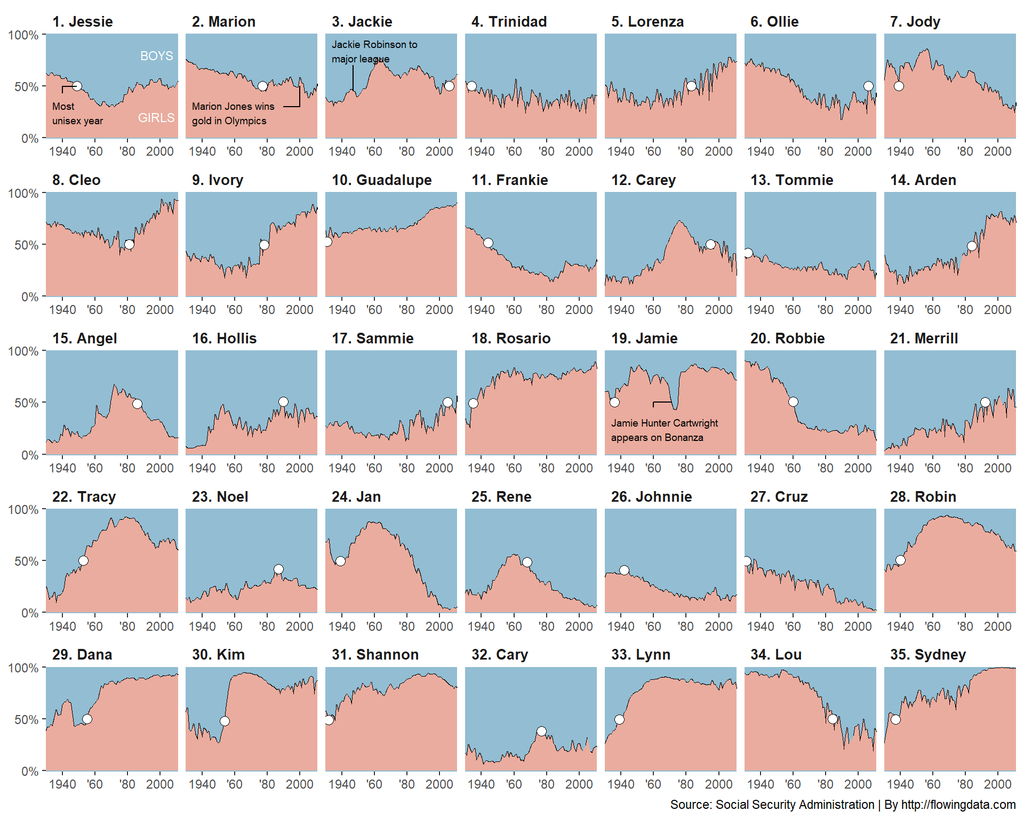

```r
ggplot(ranked_data,aes(x=year,y=pct_girls))+
  geom_line()+
  facet_wrap(~name_label, nrow=5,scales="free_x")+
  geom_area(fill = "#eaac9e")+
  geom_point(data = names_unisex_year, fill = "white", pch = 21, size = 3)+
  geom_path(data=name_segments)+
  geom_text(data=jessie_labels,aes(label=label),color="white",size=3)+
  geom_text(data=name_context,family="Century Gothic",aes(x=year_label,y=vpos,label=text,hjust=hjust),vjust="top",size=2.5)+
  scale_y_continuous(name = NULL,breaks = c(0,0.5,1),
                   labels=c("0%","50%","100%"),
                   expand = c(0,0.01)) +
  scale_x_continuous(name = NULL,breaks = c(1940,1960,1980,2000),labels=c("1940","'60","'80","2000"),expand = c(0,0)) +
  scale_fill_manual(values = c("#eaac9e", "black")) +
  theme(
    panel.background = element_rect(fill = "#92bdd3"),
    panel.grid.major = element_blank(),
    panel.grid.minor = element_blank(),
    text = element_text(family = "Century Gothic"),
    strip.background = element_blank(),
    strip.text = element_text(hjust = 0, face = "bold", size = 10)
  )+
  labs(
    caption = "Source: Social Security Administration | By http://flowingdata.com"
  )
```

Unlike our other assignments thus far, attempting to “replicate the master” posed unique challenges because we had an expected end visual and had to work backwards from there. This assignment was much more collaborative than the others because the entire class was working on the same problem. Throughout our process, we often reached out on Slack and went to office hours when we were trying to find the way ahead. While trying to replicate Yau’s graph was done as a collaborative learning exercise, it is important to also acknowledge the ethical implications of creating duplicates of another statistician’s work outside of the classroom. The skills gained from recreating an existing graphic are best applied to a unique piece of work that contributes new ideas to the data science community.

## Word count

| Method | koRpus | stringi |
| --- | --- | --- |
| Word count | 629 | 616 |
| Character count | 3851 | 3891 |
| Sentence count | 38 | Not available |
| Reading time | 3.1 minutes | 3.1 minutes |

## Standards

In this assignment, we attempted the following [standards](https://beanumber.github.io/sds192/standards.html):

- : We mastered the Wrangling standard because we employed comments to maximize readability and improved the efficiency of our data wrangling through the implementation of functions for iteration.
- : We mastered the GitHub standard because we developed methods to avoid merge conflicts through technical solutions as well as frequent communication.
- : We mastered the Context standard because we successfully recreated the original data visualization along with its annotations to provide context to the viewer.
- : We mastered the Function standard because we created 3 functions: the rmse_names function, which calculates the RMSE for each name, the unisex_names function, which creates the dataframe that is graphed, and the unisex_year function, which finds the most unisex year in each name’s set of data.
- : We mastered the Iteration standard because we successfully called the map_dfr function to loop our list of names through the aforementioned functions to gather data and create the dataframes to draw our graphic.
- : We mastered the Relational standard because we used the join function to meld our two major dataframes, sorted_names and names_data, to create a master dataframe which would be used to create our graphic.
- : We mastered the Aesthetics standard because we used a wide variety of the different color palettes and geoms at our disposal, including labels, colors, and scales, while still making sure the graphic was readable and clear.
- : We mastered the Ethics standard because we addressed the implications of the work we produced and provided proper citations and references when necessary.
- : We mastered the R Markdown standard because we utilized the YAML metadata to adjust the height of our data visualization to maintain readability across all monitor display aspect ratios.
- : We met the Reshape standard because we used joins to include the name_label factor variable across all data frames used to generate our ggplot object to maintain facet order.

## References

[^1]: (https://flowingdata.com/2013/09/25/the-most-unisex-names-in-us-history/)